# Catalysts for Innovation

Anwesha Guha

2024-03-28

```r
load(here("data/2024 data", "complete_canopy_2024.RData"))
```

## Reflections

For `catalyst_key`, here are some notable relationships/correlations (0.25 and above).

*2021*

- cutting_edge: flexible_facilities
- inequities: culturally_responsive, hiring_equity, social_justice, anti-racist, design-marginalized

*2024*

- covid: enriched_virtual
- stakeholders: adult_wellness

For just `catalyst_`, here are some notable relationships/correlations (0.25 and above).

*2021*

- cutting_edge: flexible_facilities
- inequities: culturally_responsive, social_justice, hiring_equity, anti-racist, design-marginalized

*2024*

- cutting_edge: interdisciplinary
- demographics: translanguaging
- inequities: hiring_equity

## Correlation Analysis

### Catalyst Correlations with 2021 data

```r
catalyst_dat_2021 <- dat %>%
  filter(year == 2021) %>%
  select(school_id, starts_with("catalyst_"))

tag_dat_2021 <- tag_dat %>%
  filter(year == 2021) %>%
  select(-year)

# Combine catalyst and tag files.
dat_2021 <- full_join(catalyst_dat_2021, tag_dat_2021)


# Calculate correlations for practice by catalyst.
results_catalyst_2021 <- dat_2021 %>%
  select(starts_with("catalyst_"), usage, var, -catalyst_other_text, -starts_with("catalyst_key")) %>%
  group_by(var) %>%
  summarise(across(starts_with("catalyst_"), ~round(cor(.x, usage, use="complete.obs"), 2)))

results_catalyst_2021 %>%
  datatable()
```

|  | var | catalyst_covid | catalyst_cutting_edge | catalyst_demographics | catalyst_external | catalyst_inequities | catalyst_internal | catalyst_stakeholders | catalyst_student_agency | catalyst_teacher_agency | catalyst_other |
| --- | --- | --- | --- | --- | --- | --- | --- | --- | --- | --- | --- |
| 1 | practices_a_la_carte | -0.16 | 0.07 | -0.08 | 0.03 | -0.06 | 0.03 | 0.05 | 0.12 | -0.03 | 0.06 |
| 2 | practices_accommodations | -0.05 | 0.1 | -0.07 | -0.05 | 0.05 | -0.01 | 0.04 | 0.03 | 0.04 | 0.05 |
| 3 | practices_adaptive_content | 0.02 | 0.07 | -0.02 | -0.04 | 0.09 | -0.05 | 0.05 | 0.02 | 0.05 | -0.04 |
| 4 | practices_advancement_mastery | -0.14 | 0.13 | -0.07 | 0.01 | 0.09 | -0.07 | 0.02 | 0.2 | -0.03 | -0.11 |
| 5 | practices_advisories | -0.06 | 0.05 | -0.03 | 0.15 | 0.13 | 0.08 | -0.04 | 0.06 | 0.07 | 0.08 |
| 6 | practices_alternating_days | 0.03 | 0.03 | -0.06 | 0.11 | 0.01 | -0.07 | 0.06 | -0.01 | -0.07 | 0.04 |
| 7 | practices_alternating_weeks | 0.04 | 0.09 | -0.03 | 0.1 | 0.05 | 0 | 0.12 | -0.06 | -0.06 | -0.05 |
| 8 | practices_anti_racist | -0.06 | 0.09 | -0.1 | 0 | 0.3 | -0.1 | -0.06 | -0.08 | 0.04 | -0.1 |
| 9 | practices_assessment_schedule | -0.11 | 0.06 | -0.08 | -0.05 | 0.02 | -0.07 | -0.05 | 0.06 | 0.06 | 0.09 |
| 10 | practices_assessments_career | -0.14 | 0.13 | -0.08 | 0.03 | 0 | 0.06 | 0.11 | 0.04 | 0.04 | 0.04 |

[output cut: 81 more lines]

```r
results_catalyst_key_2021 <- dat_2021 %>%
  select(starts_with("catalyst_key"), usage, var) %>%
  group_by(var) %>%
  summarise(across(starts_with("catalyst_"), ~round(cor(.x, usage, use="complete.obs"), 2)))

results_catalyst_key_2021 %>%
  datatable()
```

|  | var | catalyst_key_covid | catalyst_key_cutting_edge | catalyst_key_demographics | catalyst_key_external | catalyst_key_inequities | catalyst_key_internal | catalyst_key_stakeholders | catalyst_key_student_agency | catalyst_key_teacher_agency | catalyst_key_other |
| --- | --- | --- | --- | --- | --- | --- | --- | --- | --- | --- | --- |
| 1 | practices_a_la_carte | -0.19 | 0.06 | -0.08 | 0.04 | -0.05 | -0.03 | 0.05 | 0.13 | -0.07 | 0.07 |
| 2 | practices_accommodations | -0.08 | 0.04 | -0.07 | -0.03 | 0.02 | -0.01 | 0.04 | 0.06 | 0.08 | 0.05 |
| 3 | practices_adaptive_content | -0.01 | 0.07 | -0.02 | -0.01 | 0.05 | -0.11 | 0.06 | 0.02 | 0.05 | -0.06 |
| 4 | practices_advancement_mastery | -0.15 | 0.12 | -0.07 | 0 | 0.12 | -0.08 | 0.02 | 0.22 | 0.02 | -0.1 |
| 5 | practices_advisories | -0.09 | -0.07 | -0.03 | 0.09 | 0.1 | 0.04 | -0.05 | 0.04 | 0.02 | 0.07 |
| 6 | practices_alternating_days | 0.01 | 0.01 | -0.06 | 0.08 | 0.01 | -0.03 | 0.1 | -0.04 | -0.14 | 0.02 |
| 7 | practices_alternating_weeks | -0.01 | 0.11 | -0.03 | -0.01 | 0.07 | 0.02 | 0.14 | -0.05 | -0.04 | -0.05 |
| 8 | practices_anti_racist | -0.05 | 0.05 | -0.1 | 0.01 | 0.27 | -0.1 | -0.04 | -0.07 | 0.07 | -0.11 |
| 9 | practices_assessment_schedule | -0.18 | 0.05 | -0.08 | -0.05 | 0.02 | -0.08 | -0.05 | 0.07 | 0.14 | 0.08 |
| 10 | practices_assessments_career | -0.17 | 0.1 | -0.08 | 0.08 | -0.03 | 0.01 | 0.1 | 0.03 | -0.09 | 0.05 |

[output cut: 81 more lines]

### Catalyst Correlations with 2024 data

```r
catalyst_dat_2024 <- dat %>%
  filter(year == 2024) %>%
  select(school_id, starts_with("catalyst_"))

tag_dat_2024 <- tag_dat %>%
  filter(year == 2024) %>%
  select(-year)

# Combine catalyst and tag files.
dat_2024 <- full_join(catalyst_dat_2024, tag_dat_2024)


# Calculate correlations for practice by catalyst.
results_catalyst_2024 <- dat_2024 %>%
  select(starts_with("catalyst_"), usage, var, -catalyst_other_text, -starts_with("catalyst_key")) %>%
  group_by(var) %>%
  summarise(across(starts_with("catalyst_"), ~round(cor(.x, usage, use="complete.obs"), 2)))

results_catalyst_2024 %>%
  datatable()
```

|  | var | catalyst_covid | catalyst_cutting_edge | catalyst_demographics | catalyst_external | catalyst_inequities | catalyst_internal | catalyst_stakeholders | catalyst_student_agency | catalyst_teacher_agency | catalyst_other |
| --- | --- | --- | --- | --- | --- | --- | --- | --- | --- | --- | --- |
| 1 | practices_a_la_carte | 0.05 | -0.02 | -0.04 | 0.09 | -0.1 | 0.09 | 0.01 | 0.01 | -0.05 | -0.01 |
| 2 | practices_accommodations | -0.04 | 0.01 | -0.12 | -0.07 | -0.01 | 0.03 | -0.01 | -0.04 | -0.02 | 0.05 |
| 3 | practices_adult_wellness | -0.01 | 0.01 | 0.08 | 0.18 | 0.1 | 0.06 | 0.2 | 0.05 | -0.05 | 0.1 |
| 4 | practices_advancement_mastery | -0.12 | 0.12 | -0.08 | -0.01 | -0.06 | 0.03 | 0.08 | 0.06 | 0.06 | 0.09 |
| 5 | practices_advisories | 0.13 | 0.09 | 0.1 | 0.13 | 0.06 | -0.12 | 0.03 | 0.05 | -0.02 | -0.02 |
| 6 | practices_anti_racist | 0.03 | 0.13 | 0.02 | -0.02 | 0.07 | -0.03 | -0.04 | 0.04 | 0.03 | 0 |
| 7 | practices_assessments_agency | -0.06 | 0.22 | 0.04 | 0.16 | 0.04 | 0.06 | 0.15 | 0.05 | 0.14 | 0.17 |
| 8 | practices_assessments_bilingual | -0.03 | -0.02 | 0.03 | 0.02 | 0.2 | 0.03 | 0.03 | 0.15 | 0.11 | 0 |
| 9 | practices_assessments_career | -0.12 | 0.09 | 0.06 | 0.04 | 0.02 | 0.07 | 0.07 | 0.06 | 0.05 | -0.01 |
| 10 | practices_assessments_deeper | -0.04 | -0.04 | -0.03 | 0.04 | -0.02 | 0 | -0.06 | 0.1 | -0.02 | 0.11 |

[output cut: 63 more lines]

```r
results_catalyst_key_2024 <- dat_2024 %>%
  select(starts_with("catalyst_key"), usage, var) %>%
  group_by(var) %>%
  summarise(across(starts_with("catalyst_"), ~round(cor(.x, usage, use="complete.obs"), 2)))

results_catalyst_key_2024 %>%
  datatable()
```

|  | var | catalyst_key_covid | catalyst_key_cutting_edge | catalyst_key_demographics | catalyst_key_external | catalyst_key_inequities | catalyst_key_internal | catalyst_key_stakeholders | catalyst_key_student_agency | catalyst_key_teacher_agency | catalyst_key_other |
| --- | --- | --- | --- | --- | --- | --- | --- | --- | --- | --- | --- |
| 1 | practices_a_la_carte | 0.18 | -0.06 | -0.06 | -0.05 | 0.06 | 0.04 | 0.02 | 0.05 | -0.02 | 0.02 |
| 2 | practices_accommodations | -0.04 | 0.01 | -0.14 | -0.04 | -0.07 | 0.04 | -0.04 | 0.03 | -0.04 | 0.1 |
| 3 | practices_adult_wellness | -0.07 | 0.24 | -0.02 | 0.16 | 0.09 | 0.03 | 0.31 | 0.02 | 0 | 0.15 |
| 4 | practices_advancement_mastery | -0.11 | 0.1 | -0.04 | 0.07 | -0.1 | 0 | -0.02 | 0.02 | 0.09 | 0.14 |
| 5 | practices_advisories | 0.04 | 0.09 | 0 | 0.08 | -0.04 | -0.07 | 0.01 | 0.01 | 0.02 | 0.01 |
| 6 | practices_anti_racist | -0.04 | 0.14 | -0.05 | -0.09 | 0.04 | -0.01 | 0 | 0.05 | 0.07 | -0.04 |
| 7 | practices_assessments_agency | -0.15 | 0.21 | -0.1 | 0.13 | 0.03 | 0 | -0.03 | -0.01 | 0.08 | 0.17 |
| 8 | practices_assessments_bilingual | -0.07 | -0.01 | -0.03 | 0.02 | 0.16 | -0.06 | -0.08 | 0.19 | 0.17 | 0.07 |
| 9 | practices_assessments_career | -0.13 | 0.07 | -0.11 | 0.05 | -0.02 | 0.13 | 0.09 | -0.03 | 0.05 | 0.05 |
| 10 | practices_assessments_deeper | -0.08 | 0.09 | -0.1 | -0.03 | 0.03 | 0.03 | -0.06 | 0.05 | 0.01 | 0.11 |

[output cut: 63 more lines]

### Catalyst Update – just 2024 data

Which catalysts are unique to 2024?

```r
catalyst_dat_only_2024 <- variables %>%
  select(school_id, starts_with("catalyst_"))

setdiff(colnames(catalyst_dat_only_2024), colnames(catalyst_dat_2024))
```

```
## [1] "catalyst_absence"           "catalyst_mental_health"
## [3] "catalyst_key_absence"       "catalyst_key_mental_health"
```

- absence (chronic absenteeism)
- mental_health (mental health)

```r
tag_dat_2024 <- tag_dat %>%
  filter(year == 2024) %>%
  select(-year)

# Combine catalyst and tag files.
dat_only_2024 <- full_join(catalyst_dat_only_2024, tag_dat_2024)


# Calculate correlations for practice by catalyst.
results_catalyst_only_2024 <- dat_only_2024 %>%
  select(starts_with("catalyst_"), usage, var, -catalyst_other_text, -starts_with("catalyst_key")) %>%
  group_by(var) %>%
  summarise(across(starts_with("catalyst_"), ~round(cor(.x, usage, use="complete.obs"), 2)))

results_catalyst_only_2024 %>%
  datatable()
```

|  | var | catalyst_cutting_edge | catalyst_external | catalyst_student_agency | catalyst_teacher_agency | catalyst_demographics | catalyst_internal | catalyst_stakeholders | catalyst_inequities | catalyst_absence | catalyst_covid | catalyst_mental_health | catalyst_other |
| --- | --- | --- | --- | --- | --- | --- | --- | --- | --- | --- | --- | --- | --- |
| 1 | practices_a_la_carte | -0.02 | 0.09 | 0.01 | -0.05 | -0.04 | 0.09 | 0.01 | -0.1 | 0.22 | 0.05 | 0.07 | -0.01 |
| 2 | practices_accommodations | 0.01 | -0.07 | -0.04 | -0.02 | -0.12 | 0.03 | -0.01 | -0.01 | 0.05 | -0.04 | 0.12 | 0.05 |
| 3 | practices_adult_wellness | 0.01 | 0.18 | 0.05 | -0.05 | 0.08 | 0.06 | 0.2 | 0.1 | 0.11 | -0.01 | 0.24 | 0.1 |
| 4 | practices_advancement_mastery | 0.12 | -0.01 | 0.06 | 0.06 | -0.08 | 0.03 | 0.08 | -0.06 | -0.1 | -0.12 | 0.03 | 0.09 |
| 5 | practices_advisories | 0.09 | 0.13 | 0.05 | -0.02 | 0.1 | -0.12 | 0.03 | 0.06 | 0.01 | 0.13 | 0.1 | -0.02 |
| 6 | practices_anti_racist | 0.13 | -0.02 | 0.04 | 0.03 | 0.02 | -0.03 | -0.04 | 0.07 | -0.01 | 0.03 | 0.08 | 0 |
| 7 | practices_assessments_agency | 0.22 | 0.16 | 0.05 | 0.14 | 0.04 | 0.06 | 0.15 | 0.04 | -0.04 | -0.06 | 0.1 | 0.17 |
| 8 | practices_assessments_bilingual | -0.02 | 0.02 | 0.15 | 0.11 | 0.03 | 0.03 | 0.03 | 0.2 | -0.07 | -0.03 | 0.04 | 0 |
| 9 | practices_assessments_career | 0.09 | 0.04 | 0.06 | 0.05 | 0.06 | 0.07 | 0.07 | 0.02 | 0.08 | -0.12 | 0.13 | -0.01 |
| 10 | practices_assessments_deeper | -0.04 | 0.04 | 0.1 | -0.02 | -0.03 | 0 | -0.06 | -0.02 | 0.02 | -0.04 | -0.01 | 0.11 |

[output cut: 63 more lines]

```r
results_catalyst_key_only_2024 <- dat_only_2024 %>%
  select(starts_with("catalyst_key"), usage, var) %>%
  group_by(var) %>%
  summarise(across(starts_with("catalyst_"), ~round(cor(.x, usage, use="complete.obs"), 2)))

results_catalyst_key_only_2024 %>%
  datatable()
```

|  | var | catalyst_key_cutting_edge | catalyst_key_external | catalyst_key_student_agency | catalyst_key_teacher_agency | catalyst_key_demographics | catalyst_key_internal | catalyst_key_stakeholders | catalyst_key_inequities | catalyst_key_absence | catalyst_key_covid | catalyst_key_mental_health | catalyst_key_other |
| --- | --- | --- | --- | --- | --- | --- | --- | --- | --- | --- | --- | --- | --- |
| 1 | practices_a_la_carte | -0.06 | -0.05 | 0.05 | -0.02 | -0.06 | 0.04 | 0.02 | 0.06 | 0.18 | 0.18 | 0.16 | 0.02 |
| 2 | practices_accommodations | 0.01 | -0.04 | 0.03 | -0.04 | -0.14 | 0.04 | -0.04 | -0.07 | 0.04 | -0.04 | 0.03 | 0.1 |
| 3 | practices_adult_wellness | 0.24 | 0.16 | 0.02 | 0 | -0.02 | 0.03 | 0.31 | 0.09 | -0.02 | -0.07 | 0.1 | 0.15 |
| 4 | practices_advancement_mastery | 0.1 | 0.07 | 0.02 | 0.09 | -0.04 | 0 | -0.02 | -0.1 | -0.1 | -0.11 | 0 | 0.14 |
| 5 | practices_advisories | 0.09 | 0.08 | 0.01 | 0.02 | 0 | -0.07 | 0.01 | -0.04 | 0.1 | 0.04 | 0.11 | 0.01 |
| 6 | practices_anti_racist | 0.14 | -0.09 | 0.05 | 0.07 | -0.05 | -0.01 | 0 | 0.04 | -0.12 | -0.04 | 0.03 | -0.04 |
| 7 | practices_assessments_agency | 0.21 | 0.13 | -0.01 | 0.08 | -0.1 | 0 | -0.03 | 0.03 | -0.06 | -0.15 | -0.02 | 0.17 |
| 8 | practices_assessments_bilingual | -0.01 | 0.02 | 0.19 | 0.17 | -0.03 | -0.06 | -0.08 | 0.16 | -0.06 | -0.07 | -0.05 | 0.07 |
| 9 | practices_assessments_career | 0.07 | 0.05 | -0.03 | 0.05 | -0.11 | 0.13 | 0.09 | -0.02 | 0.08 | -0.13 | -0.01 | 0.05 |
| 10 | practices_assessments_deeper | 0.09 | -0.03 | 0.05 | 0.01 | -0.1 | 0.03 | -0.06 | 0.03 | 0.03 | -0.08 | -0.01 | 0.11 |

[output cut: 63 more lines]

### Catalyst Correlations (with each other)

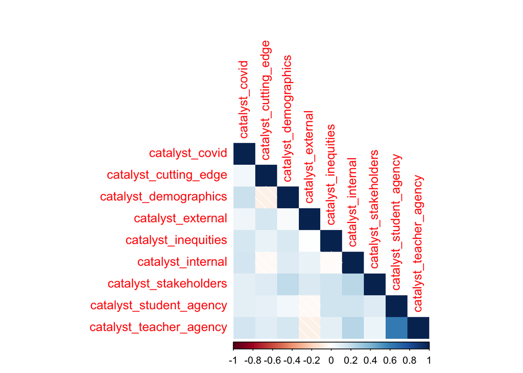

```r
catalyst_cor <- cor(catalyst_dat_2024[2:10], use = "pairwise.complete.obs")  # exclude other columns, like id, key, & other

corrplot::corrplot(catalyst_cor, method = "shade", type = "lower")
```

### Catalysts by Clusters

For 2024:

```r
old_clusters <- import(here("data/clusters_through_2024.csv"))
cluster_dat <- left_join(tag_dat_2024, old_clusters)

dat_only_2024 <- full_join(catalyst_dat_only_2024, cluster_dat)

results_catalyst_only_2024 <- dat_only_2024 %>%
  select(starts_with("catalyst_"), usage, cluster, -catalyst_other_text, -starts_with("catalyst_key")) %>%
  group_by(cluster) %>%
  summarise(across(starts_with("catalyst_"), ~round(cor(.x, usage, use="complete.obs"), 2))) %>%
  pivot_longer(!cluster, names_to = "catalyst", values_to = "correlation") %>%
  pivot_wider(names_from = cluster,
              values_from = correlation)

results_catalyst_only_2024 %>%
  datatable()
```

|  | catalyst | Deeper learning | Ed justice | Individualized | None | Postsecondary |
| --- | --- | --- | --- | --- | --- | --- |
| 1 | catalyst_cutting_edge | 0.09 | 0 | -0.07 | 0.03 | 0.03 |
| 2 | catalyst_external | 0.04 | 0.02 | 0.02 | 0.05 | 0.07 |
| 3 | catalyst_student_agency | 0.08 | 0.02 | 0.01 | 0.04 | 0 |
| 4 | catalyst_teacher_agency | 0.03 | 0.02 | 0.03 | 0.03 | -0.02 |
| 5 | catalyst_demographics | -0.02 | 0.05 | -0.03 | 0.02 | 0.03 |
| 6 | catalyst_internal | 0.03 | 0.01 | 0.02 | 0.01 | 0.04 |
| 7 | catalyst_stakeholders | 0 | 0 | -0.03 | 0.04 | 0.04 |
| 8 | catalyst_inequities | -0.03 | 0.1 | 0 | 0.03 | 0.04 |
| 9 | catalyst_absence | 0 | 0.05 | 0.06 | -0.02 | 0.1 |
| 10 | catalyst_covid | -0.09 | 0.02 | 0.06 | -0.01 | -0.04 |

[output cut: 2 more lines]

## Changes over Time

```r
source(here("scripts/branding.R"))
```

Evolution of catalyst questions (changes to questions from 2021):

- Desire to be on the cutting edge and demonstrate what’s possible – *same*
- External catalyst events (e.g., a partnership, a visit to another school, an unexpected source of funding) – *same*
- Lack of student agency – *same*
- Lack of teacher agency – *same*
- Change in demographics in our community – *“in our community” added*
- Negative factors inside the school (e.g., toxic culture, low achievement) – *same*
- Stakeholder demand or advocacy (e.g., from the community, district leadership, teachers, or state agency) – *same*
- Systemic inequities (e.g., racism, poverty) – *same*
- Chronic absenteeism – *ADDED*
- Learning disruptions due to COVID – *changed from “School building closures related to COVID-19”*
- Mental health concerns – *ADDED*
- Other (please specify) __________ – *same*

```r
catalyst_dat_long <- dat %>%
  filter(year == 2021 | year == 2024) %>%
  select(school_id, year, starts_with("catalyst_")) %>%
  select(-starts_with("catalyst_key"), -starts_with("catalyst_other"))

catalyst_key_dat_long <- dat %>%
  filter(year == 2021 | year == 2024) %>%
  select(school_id, year, starts_with("catalyst_key")) %>%
  select(-starts_with("catalyst_key_other"))
```

### Across Schools

For just catalyst:

```r
catalyst_dat <- catalyst_dat_long %>%
  pivot_longer(cols = -c(school_id, year),
               names_to = "catalyst",
               values_to = "usage",
               names_pattern = "^catalyst_(.*)$")

catalyst_use <- catalyst_dat %>%
  group_by(catalyst, year) %>%
  summarize(total_use = sum(usage))
```

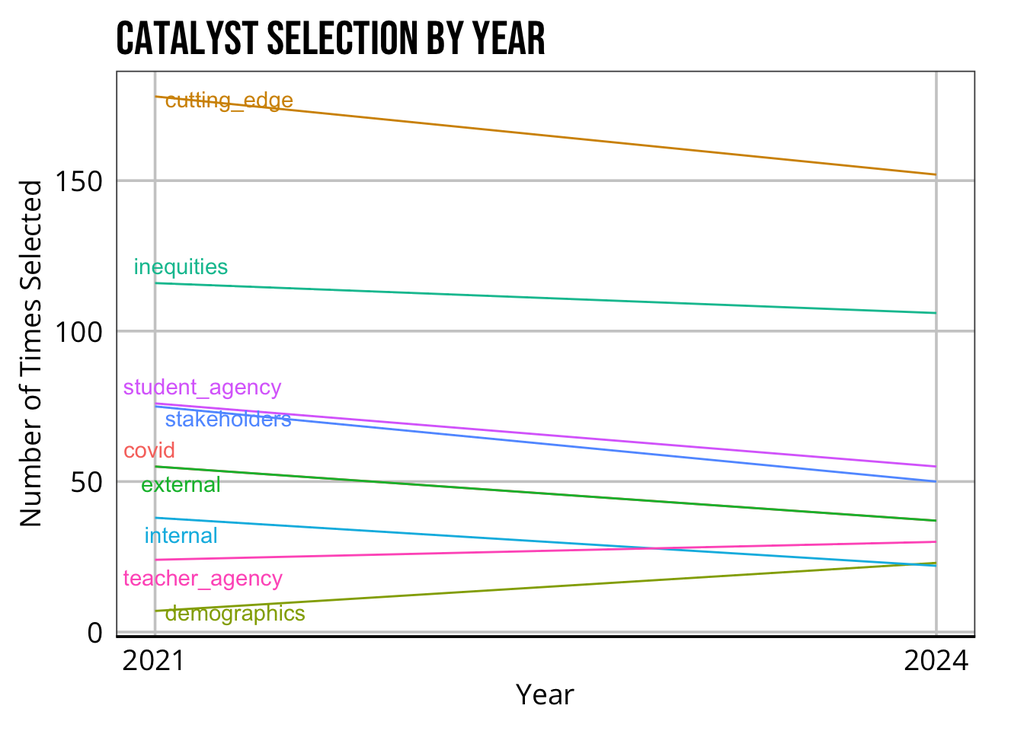

```r
library(ggrepel)
label_positions <- catalyst_use %>%
  group_by(catalyst) %>%
  summarize(year = 2021, total_use = first(total_use))

catalyst_use %>%
  ggplot(aes(x = year, y = total_use, color = catalyst)) +
  geom_line() +
  geom_text_repel(data = label_positions, aes(label = catalyst)) +
  scale_x_continuous(breaks = c(2021, 2024)) +
  labs(x = "Year",
       y = "Number of Times Selected",
       title = "Catalyst Selection by Year") +
  theme(legend.position = "none")
```

*Note:* Demographics and teacher_agency are increasingly selected as a catalyst for innovation, though selection for other catalyst categories on the whole have decreased.

For catalyst_key:

```r
catalyst_key_dat <- catalyst_key_dat_long %>%
  pivot_longer(cols = -c(school_id, year),
               names_to = "catalyst_key",
               values_to = "usage",
               names_pattern = "^catalyst_key_(.*)$")

catalyst_key_use <- catalyst_key_dat %>%
  group_by(catalyst_key, year) %>%
  summarize(total_use = sum(usage))
```

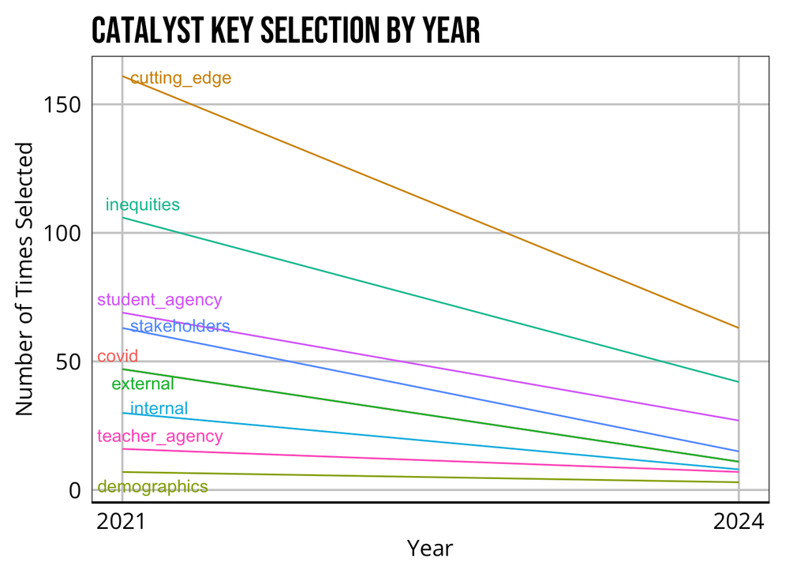

```r
label_positions <- catalyst_key_use %>%
  group_by(catalyst_key) %>%
  summarize(year = 2021, total_use = first(total_use))

catalyst_key_use %>%
  ggplot(aes(x = year, y = total_use, color = catalyst_key)) +
  geom_line() +
  geom_text_repel(data = label_positions, aes(label = catalyst_key)) +
  scale_x_continuous(breaks = c(2021, 2024)) +
  labs(x = "Year",
       y = "Number of Times Selected",
       title = "Catalyst Key Selection by Year") +
  theme(legend.position = "none")
```

### Within Schools

For just catalyst:

```r
repeat_sch_catalyst <- catalyst_dat_long[duplicated(catalyst_dat_long$school_id) | duplicated(catalyst_dat_long$school_id, fromLast = TRUE),]

repeat_sch_catalyst_long <- repeat_sch_catalyst %>%
  pivot_longer(cols = -c(school_id, year),
               names_to = "catalyst",
               values_to = "usage",
               names_pattern = "^catalyst_(.*)$")

repeat_sch_catalyst_long <- repeat_sch_catalyst_long %>%
  pivot_wider(names_from = "year",
              values_from = "usage")

repeat_sch_catalyst_long <- repeat_sch_catalyst_long %>%
  mutate(status = case_when(`2021` == 1 & `2024` == 1 ~ "selected both years",
                            `2021` == 1 & `2024` == 0 ~ "dropped",
                            `2021` == 0 & `2024` == 1 ~ "added",
                            `2021` == 0 & `2024` == 0 ~ "never selected"))
```

```r
catalyst_status_dat <- repeat_sch_catalyst_long %>%
  group_by(catalyst, status) %>%
  summarise(n = n()) %>%
  pivot_wider(names_from = "status",
              values_from = "n")

catalyst_status_dat %>%  datatable()
```

|  | catalyst | added | dropped | never selected | selected both years |
| --- | --- | --- | --- | --- | --- |
| 1 | covid | 14 | 13 | 51 | 4 |
| 2 | cutting_edge | 11 | 13 | 8 | 50 |
| 3 | demographics | 9 | 1 | 70 | 2 |
| 4 | external | 9 | 18 | 47 | 8 |
| 5 | inequities | 20 | 17 | 20 | 25 |
| 6 | internal | 5 | 11 | 63 | 3 |
| 7 | stakeholders | 8 | 22 | 42 | 10 |
| 8 | student_agency | 6 | 20 | 41 | 15 |
| 9 | teacher_agency | 7 | 4 | 65 | 6 |

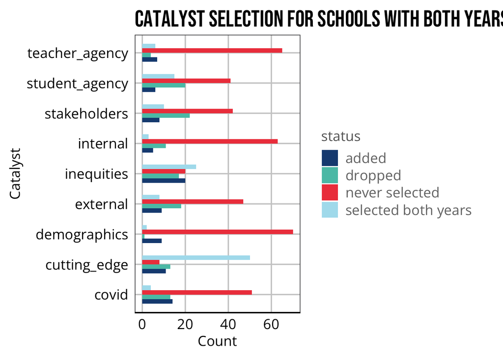

```r
repeat_cat_viz <- repeat_sch_catalyst_long %>%
  count(catalyst, status)

repeat_cat_viz %>%
  ggplot(aes(x = catalyst, y = n, fill = status)) +
  geom_col(position = "dodge") +
  coord_flip() +
  scale_fill_manual(values = transcend_cols) +
  labs(title = "Catalyst Selection for Schools with Both Years of Data",
       x = "Catalyst",
       y = "Count",
       legend = "Status")
```

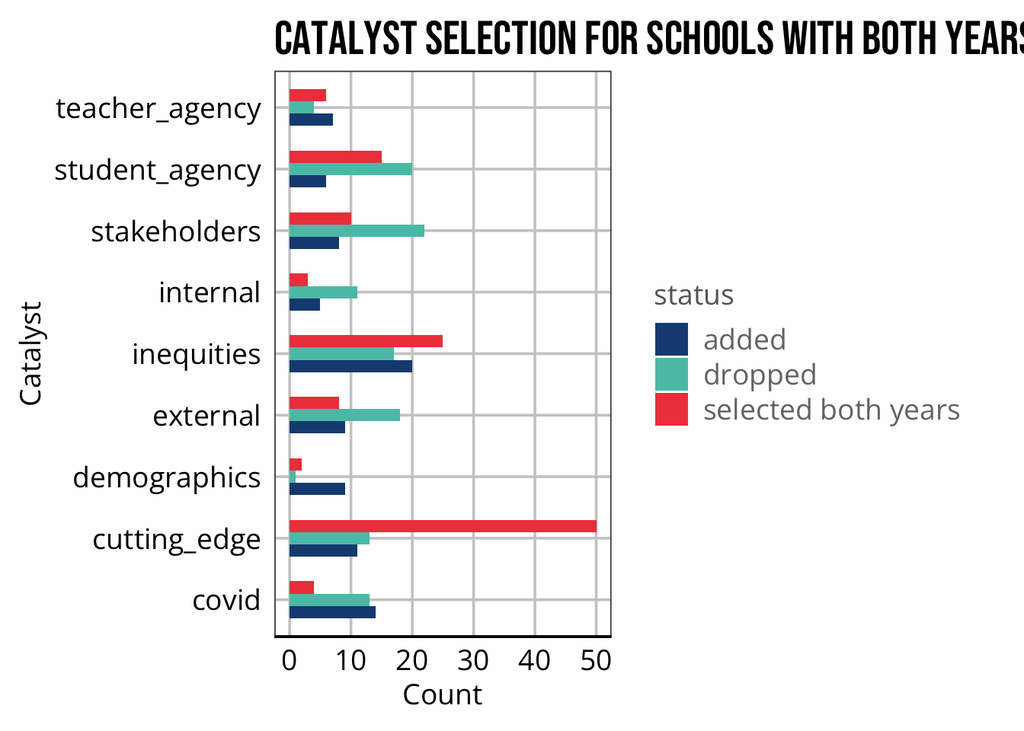

```r
repeat_cat_viz <- repeat_sch_catalyst_long %>%
  count(catalyst, status) %>%
  filter(status != "never selected")

repeat_cat_viz %>%
  ggplot(aes(x = catalyst, y = n, fill = status)) +
  geom_col(position = "dodge") +
  coord_flip() +
  scale_fill_manual(values = transcend_cols) +
  labs(title = "Catalyst Selection for Schools with Both Years of Data",
       x = "Catalyst",
       y = "Count",
       legend = "Status")
```

Cutting edge was byfar the most selected catalyst for schools with two years of data.

### May 13 modification – Create version within school using percentage

```r
within_selection_catalyst <- repeat_sch_catalyst_long %>%
  group_by(catalyst) %>%
  summarise(selected_2021 = sum(`2021`),
            selected_2024 = sum(`2024`)) %>%
  mutate(pct_2021 = selected_2021/sum(selected_2021),
         pct_2024 = selected_2024/sum(selected_2024)) %>%
  select(-c(selected_2021, selected_2024)) %>%
  pivot_longer(cols = starts_with("pct"),
               names_to = "year",
               values_to = "percent",
               names_prefix = "pct_") %>%
  mutate(year = as.integer(year))
```

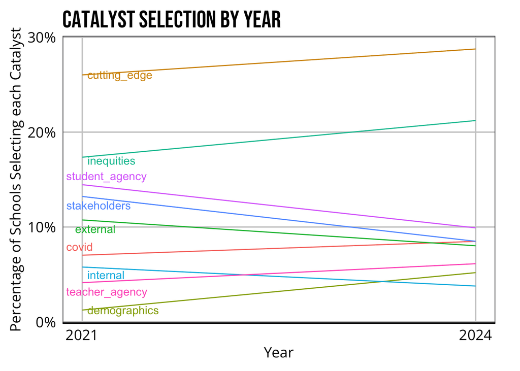

```r
label_positions <- within_selection_catalyst %>%
  group_by(catalyst) %>%
  summarize(year = 2021, percent = first(percent))

within_selection_catalyst %>%
  ggplot(aes(x = year, y = percent, color = catalyst)) +
  geom_line() +
  geom_text_repel(data = label_positions, aes(label = catalyst)) +
  scale_x_continuous(breaks = c(2021, 2024)) +
  scale_y_continuous(labels = percent_format()) +
  labs(x = "Year",
       y = "Percentage of Schools Selecting each Catalyst",
       title = "Catalyst Selection by Year") +
  theme(legend.position = "none")
```

#### Just one catalyst selected

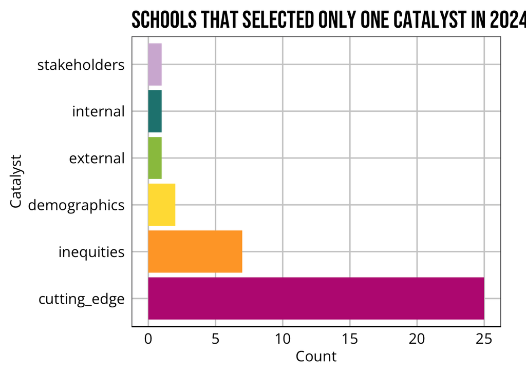

```r
single_use_cat_dat <- catalyst_dat %>%
  filter(usage == 1 & year == 2024) %>%
  group_by(school_id) %>%
  filter(n() == 1) %>%
  ungroup()

single_use_cat_dat$catalyst <- factor(single_use_cat_dat$catalyst, levels = names(sort(table(single_use_cat_dat$catalyst), decreasing = TRUE))) #sort decreasing

single_use_cat_dat %>%
  ggplot(aes(x = catalyst)) +
  geom_bar(aes(fill = catalyst)) +
  coord_flip() +
  scale_fill_manual(values = transcend_cols2) +
  labs(title = "Schools that Selected Only One Catalyst in 2024",
       x = "Catalyst",
       y = "Count") +
  theme(legend.position = "none")
```

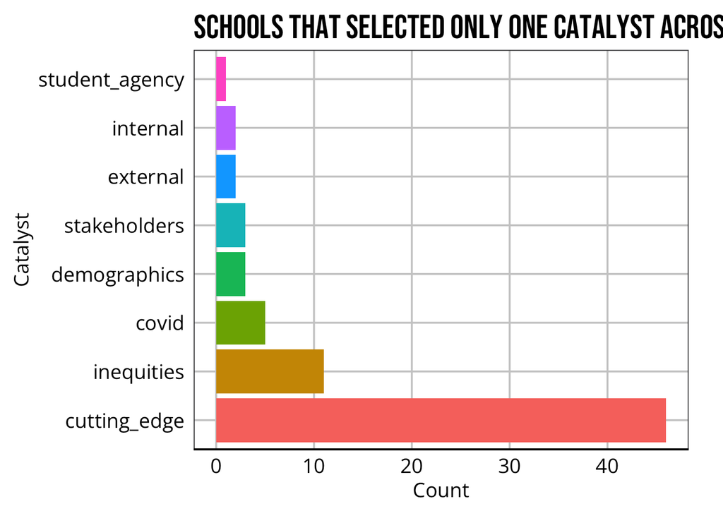

```r
single_use_cat_dat2 <- catalyst_dat %>%
  filter(usage == 1 & year == 2021) %>%
  group_by(school_id) %>%
  filter(n() == 1) %>%
  ungroup()

single_use_cat_dat_all <- bind_rows(single_use_cat_dat, single_use_cat_dat2)

single_use_cat_dat_all$catalyst <- factor(single_use_cat_dat_all$catalyst, levels = names(sort(table(single_use_cat_dat_all$catalyst), decreasing = TRUE))) #sort decreasing

single_use_cat_dat_all %>%
  ggplot(aes(x = catalyst)) +
  geom_bar(aes(fill = catalyst)) +
  coord_flip() +
#  scale_fill_manual(values = transcend_cols) +
  labs(title = "Schools that Selected Only One Catalyst across Years",
       x = "Catalyst",
       y = "Count") +
  theme(legend.position = "none")
```

Interestingly, basically no schools only selected one catalyst both years. There was only one school, school **24**, that was the anomaly, and they switched from *inequities* to *demographics*.

For catalyst_key:

```r
repeat_sch_catalyst_key <- catalyst_key_dat_long[duplicated(catalyst_key_dat_long$school_id) | duplicated(catalyst_key_dat_long$school_id, fromLast = TRUE),]

repeat_sch_catalyst_key_long <- repeat_sch_catalyst_key %>%
  pivot_longer(cols = -c(school_id, year),
               names_to = "catalyst_key",
               values_to = "usage",
               names_pattern = "^catalyst_key_(.*)$")

repeat_sch_catalyst_key_long <- repeat_sch_catalyst_key_long %>%
  pivot_wider(names_from = "year",
              values_from = "usage")

repeat_sch_catalyst_key_long <- repeat_sch_catalyst_key_long %>%
  mutate(status = case_when(`2021` == 1 & `2024` == 1 ~ "selected both years",
                            `2021` == 1 & `2024` == 0 ~ "dropped",
                            `2021` == 0 & `2024` == 1 ~ "added",
                            `2021` == 0 & `2024` == 0 ~ "never selected"))
```

```r
catalyst_key_status_dat <- repeat_sch_catalyst_key_long %>%
  group_by(catalyst_key, status) %>%
  summarise(n = n()) %>%
  pivot_wider(names_from = "status",
              values_from = "n")

catalyst_key_status_dat %>%  datatable()
```

|  | catalyst_key | added | dropped | never selected | selected both years |
| --- | --- | --- | --- | --- | --- |
| 1 | covid | 4 | 14 | 64 |  |
| 2 | cutting_edge | 8 | 39 | 18 | 17 |
| 3 | demographics |  | 2 | 79 | 1 |
| 4 | external | 3 | 19 | 58 | 2 |
| 5 | inequities | 10 | 29 | 35 | 8 |
| 6 | internal | 2 | 8 | 72 |  |
| 7 | stakeholders | 2 | 23 | 54 | 3 |
| 8 | student_agency | 2 | 23 | 50 | 7 |
| 9 | teacher_agency | 3 | 9 | 70 |  |

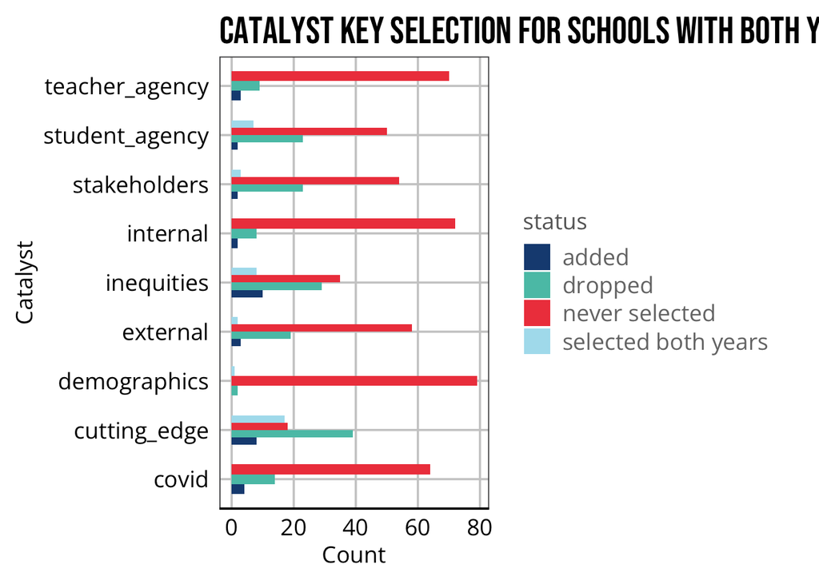

```r
repeat_catkey_viz <- repeat_sch_catalyst_key_long %>%
  count(catalyst_key, status)

repeat_catkey_viz %>%
  ggplot(aes(x = catalyst_key, y = n, fill = status)) +
  geom_col(position = "dodge") +
  coord_flip() +
  scale_fill_manual(values = transcend_cols) +
  labs(title = "Catalyst Key Selection for Schools with Both Years of Data",
       x = "Catalyst",
       y = "Count",
       legend = "Status")
```

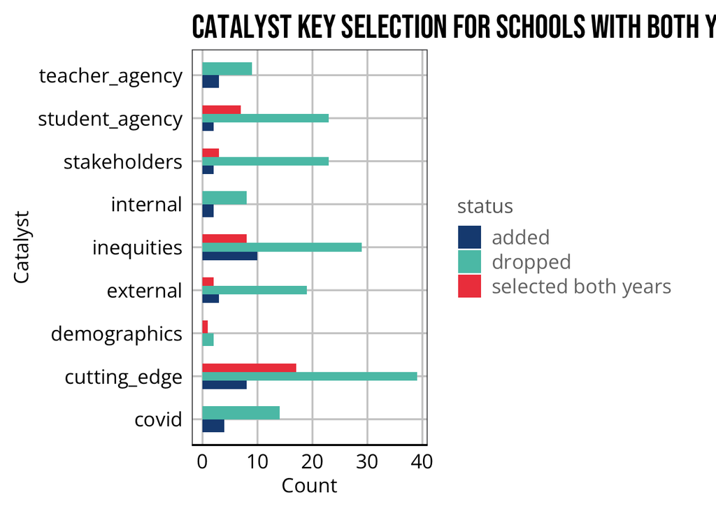

```r
repeat_catkey_viz <- repeat_sch_catalyst_key_long %>%
  count(catalyst_key, status) %>%
  filter(status != "never selected")

repeat_catkey_viz %>%
  ggplot(aes(x = catalyst_key, y = n, fill = status)) +
  geom_col(position = "dodge") +
  coord_flip() +
  scale_fill_manual(values = transcend_cols) +
  labs(title = "Catalyst Key Selection for Schools with Both Years of Data",
       x = "Catalyst",
       y = "Count",
       legend = "Status")
```

## Catalyst Groups

```r
cat_combinations <- catalyst_dat_2024 %>%
  select(1:10) %>%   #just selecting catalyst vars
  rowwise() %>%
  mutate(combination = toString(names(.)[which(unlist(c_across(where(is.numeric))) == 1)])) %>%
  ungroup() %>%
  count(combination, sort = TRUE) %>%
  slice(-3) #missing values, just hard coding bc NA wasn't working for some reason
```

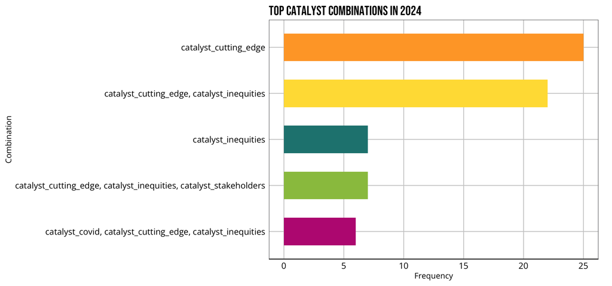

```r
ggplot(cat_combinations[1:5, ], aes(x = reorder(combination, n), y = n, fill = combination)) +
  geom_col() +
  labs(title = "Top Catalyst Combinations in 2024",
       x = "Combination",
       y = "Frequency") +
  coord_flip() +
  scale_fill_manual(values = transcend_cols2) +
  theme(legend.position = "none",
        axis.text = element_text(size = 15))
```

Compare to 2021:

```r
cat_combinations <- catalyst_dat_2021 %>%
  select(1:10) %>%   #just selecting catalyst vars
  rowwise() %>%
  mutate(combination = toString(names(.)[which(unlist(c_across(where(is.numeric))) == 1)])) %>%
  ungroup() %>%
  count(combination, sort = TRUE) %>%
  slice(-7) #missing values, just hard coding bc NA wasn't working for some reason
```

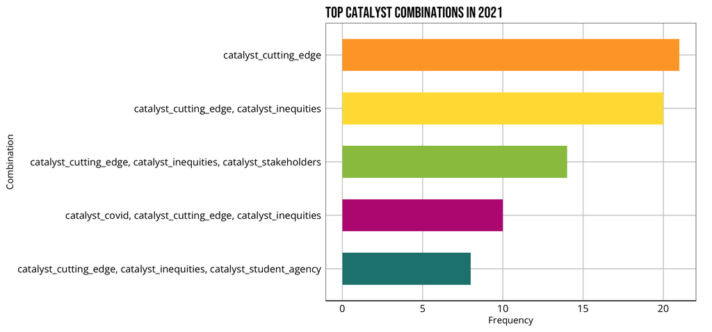

```r
ggplot(cat_combinations[1:5, ], aes(x = reorder(combination, n), y = n, fill = combination)) +
  geom_col() +
  labs(title = "Top Catalyst Combinations in 2021",
       x = "Combination",
       y = "Frequency") +
  coord_flip() +
  scale_fill_manual(values = transcend_cols2) +
  theme(legend.position = "none",
        axis.text = element_text(size = 15))
```